# Heart Failure Dataset Analysis

Stefano Andreoli, Federico Cesare Cattò, Andrea Matteo Re

2024-04-24

## Introduzione

Per questo progetto abbiamo trattato il dataset Heart Failure Dataset (https://www.kaggle.com/datasets/fedesoriano/heart-failure-prediction).

Le malattie cardiovascolari rappresentano una sfida significativa per la salute pubblica in tutto il mondo, con milioni di persone colpite ogni anno. L’utilizzo di modelli di apprendimento automatico può essere una risorsa preziosa nel rilevare tempestivamente i rischi e nell’implementare interventi preventivi mirati. Attraverso l’analisi dei dati che includono caratteristiche rilevanti per le malattie cardiache, è possibile sviluppare strumenti predittivi che aiutano a individuare potenziali problemi cardiaci prima che diventino gravi, consentendo una diagnosi e una gestione precoce.

## Dataset e variabili

Il dataset è stato realizzato dalla combinazione di cinque datasets su dodici caratteristiche comuni. Tale combinazione rende il dataset la più grande fonte di dati sulle malattie cardiache per scopi di ricerca finora disponibile.

Comprende 918 osservazioni aventi le 12 caratteristiche seguenti:

- **Age**: età del paziente (anni)
- **Sex**: sesso del paziente
  - M: Maschio
  - F: Femmina
- **ChestPainType**: tipo di dolore toracico (il termine “Angina” deriva dal latino e sta a indicare la presenza di un particolare dolore al torace).
  - TA: angina tipica
  - ATA: angina atipica (non si presenta con i sintomi classici)
  - NAP: dolore non anginoso
  - ASY: asintomatico (assenza di dolore)
- **RestingBP**: pressione arteriosa a riposo (mm/Hg)
- **Cholesterol**: colesterolo sierico (mm/dl)
- **FastingBS**: glicemia a digiuno
  - 1: se glicemia a digiuno > 120 mg/dl
  - 0: altrimenti
- **RestingECG**: elettrocardiogramma a riposo.
  - Normale: Normale
  - ST: con anomalia dell’onda ST-T (inversioni dell’onda T e/o sopraslivellamento del tratto ST o depressione di > 0,05 mV)
  - LVH: che mostra ipertrofia ventricolare sinistra.
- **MaxHR**: frequenza cardiaca massima raggiunta (Valore numerico compreso tra 60 e 202).
- **ExerciseAngina**: angina indotta dall’esercizio.
  - Y:sì
  - N:no
- **Oldpeak**: sottoslivellamento del segmento ST ( termine che si riferisce alla posizione del segmento ST nell’ECG del paziente) sotto sforzo rispetto ad una situazione di riposo. (Fig.1)

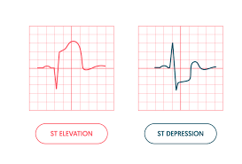

Fig.1: esempi di sovra o sottoslivellamento del segmento ST

- **ST_Slope**: la pendenza del segmento ST nel momento di massimo sforzo. (Fig.2)
  - Up: crescente
  - Flat: costante
  - Down: decrescente

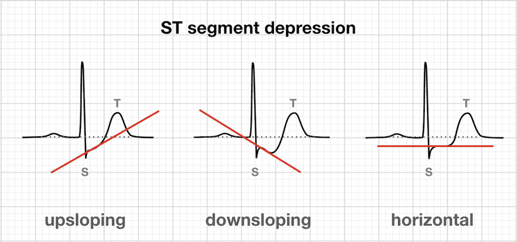

Fig.2: tipi di pendenza del segmento ST

- **HeartDisease**: variabile target
  - 1: patologia cardiaca
  - 0: normale

## Data understanding & preparation

Inserimento libraries e importazione dataset.

```r
library(MASS)
library(tidyverse)
library(ISLR)
library(tree)
library(ggcorrplot)
library(visdat)
library(mice)
library(naniar)
library(UpSetR)
library(VIM)
library(GGally)
library(cowplot)
library(car)
library(gridExtra)
library(heplots)
library(mclust)
library(class)
library(caret)
library(ROCR)
select=dplyr::select
heart=read.csv("C:/Users/fccat/Documents/Projects/Heart_Failure_Analysis/heart.csv",stringsAsFactors = T)
heart$FastingBS=as.factor(heart$FastingBS)
heart$HeartDisease=as.factor(heart$HeartDisease)
```

### Missing values

Verifichiamo la presenza di valori mancanti nel dataset.

```r
any_na(heart)
```

```
## [1] FALSE
```

Procediamo con un *summary* per controllare i range delle variabili.

```r
summary(heart)
```

```
##       Age        Sex     ChestPainType   RestingBP      Cholesterol
##  Min.   :28.00   F:193   ASY:496       Min.   :  0.0   Min.   :  0.0
##  1st Qu.:47.00   M:725   ATA:173       1st Qu.:120.0   1st Qu.:173.2
##  Median :54.00           NAP:203       Median :130.0   Median :223.0
##  Mean   :53.51           TA : 46       Mean   :132.4   Mean   :198.8
##  3rd Qu.:60.00                         3rd Qu.:140.0   3rd Qu.:267.0
##  Max.   :77.00                         Max.   :200.0   Max.   :603.0
##  FastingBS  RestingECG      MaxHR       ExerciseAngina    Oldpeak
##  0:704     LVH   :188   Min.   : 60.0   N:547          Min.   :-2.6000
##  1:214     Normal:552   1st Qu.:120.0   Y:371          1st Qu.: 0.0000
##            ST    :178   Median :138.0                  Median : 0.6000
##                         Mean   :136.8                  Mean   : 0.8874
##                         3rd Qu.:156.0                  3rd Qu.: 1.5000
##                         Max.   :202.0                  Max.   : 6.2000
##  ST_Slope   HeartDisease
##  Down: 63   0:410
##  Flat:460   1:508
##  Up  :395
##
##
##
```

Le variabili **RestingBP** e **Cholesterol** non possono assumere zero come valore, notiamo come ciò invece accada nei nostri dati. Deduciamo che essi sono dei missing values. Assegnamo a questi dei valori univoci per codificarli.

```r
heart$Cholesterol[heart$Cholesterol==0]=NA
heart$RestingBP[heart$RestingBP==0]=NA
summary(heart)
```

```
##       Age        Sex     ChestPainType   RestingBP      Cholesterol
##  Min.   :28.00   F:193   ASY:496       Min.   : 80.0   Min.   : 85.0
##  1st Qu.:47.00   M:725   ATA:173       1st Qu.:120.0   1st Qu.:207.2
##  Median :54.00           NAP:203       Median :130.0   Median :237.0
##  Mean   :53.51           TA : 46       Mean   :132.5   Mean   :244.6
##  3rd Qu.:60.00                         3rd Qu.:140.0   3rd Qu.:275.0
##  Max.   :77.00                         Max.   :200.0   Max.   :603.0
##                                        NA's   :1       NA's   :172
##  FastingBS  RestingECG      MaxHR       ExerciseAngina    Oldpeak
##  0:704     LVH   :188   Min.   : 60.0   N:547          Min.   :-2.6000
##  1:214     Normal:552   1st Qu.:120.0   Y:371          1st Qu.: 0.0000
##            ST    :178   Median :138.0                  Median : 0.6000
##                         Mean   :136.8                  Mean   : 0.8874
##                         3rd Qu.:156.0                  3rd Qu.: 1.5000
##                         Max.   :202.0                  Max.   : 6.2000
##
##  ST_Slope   HeartDisease
##  Down: 63   0:410
##  Flat:460   1:508
##  Up  :395
##
##
##
##
```

Sono presenti 172 valori mancanti per la variabile **Cholesterol**, mentre solo uno per **RestingBP**. Adottiamo una strategia passiva per **RestingBP**, eliminando l’unica riga senza valore.

```r
heart=heart%>%filter(!is.na(RestingBP))
```

Per quanto riguarda **Cholesterol**, adotteremo una strategia attiva.

Intanto ci occupiamo dello splitting del dataset in training,validation e test set.

```r
set.seed(1)
test.index=sample(c(0:nrow(heart)),size = 0.2*nrow(heart),F)
test=heart[test.index,]
train_valid=anti_join(heart,test)
validation=train_valid%>%slice_sample(prop=0.2/0.8)
training=anti_join(train_valid,validation)
```

Verifica bilanciamento della classe target nei sottoinsiemi creati.

```r
table(training$HeartDisease)/nrow(training)
```

```
##
##         0         1
## 0.4402174 0.5597826
```

```r
table(validation$HeartDisease)/nrow(validation)
```

```
##
##         0         1
## 0.4699454 0.5300546
```

```r
table(test$HeartDisease)/nrow(test)
```

```
##
##         0         1
## 0.4450549 0.5549451
```

Oltre ad un bilanciamento tra i vari dataset, riscrontriamo anche un bilanciamento tra le due classi della variabile target.

Creiamo una funzione per il calcolo di determinate metriche di valutazione quali *accuracy* e *sensitivity*, essa accetterà in input una confusion matrix.

```r
metriche=function(tab){
  accuracy=sum(diag(tab))/sum(tab)
  sensitivity=tab[2,2]/sum(tab[,2])
  return(c("Accuracy"=accuracy,"Sensitivity"=sensitivity))
}
```

Valutazione della tipologia e distribuzione dei missing values.

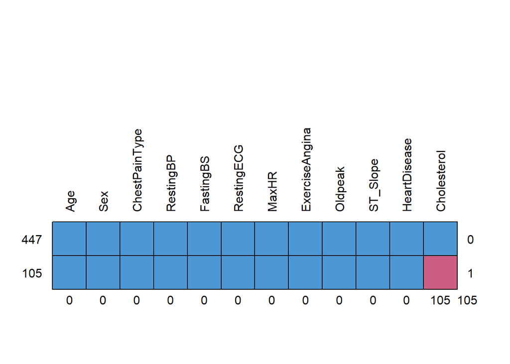

```
##     Age Sex ChestPainType RestingBP FastingBS RestingECG MaxHR ExerciseAngina
## 447   1   1             1         1         1          1     1              1
## 105   1   1             1         1         1          1     1              1
##       0   0             0         0         0          0     0              0
##     Oldpeak ST_Slope HeartDisease Cholesterol
## 447       1        1            1           1   0
## 105       1        1            1           0   1
##           0        0            0         105 105
```

```r
md.pattern(training, rotate.names=T)
```

Come avevamo visto sono tutti concentrati nella variabile **Cholesterol**.

Controlliamo ora la tipologia di missing values (MAR,MCAR,NMAR).

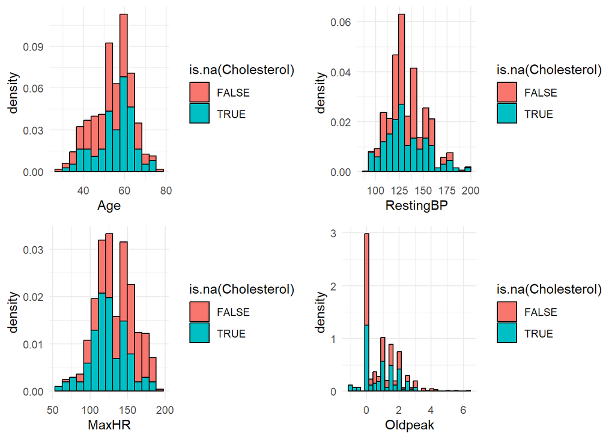

```r
g1=ggplot(training,aes(x=Age,y=after_stat(density)))+
  geom_histogram(aes(fill=is.na(Cholesterol)),col="black",bins=15)+
  theme_minimal()
g2=ggplot(training,aes(x=RestingBP,y=after_stat(density)))+
  geom_histogram(aes(fill=is.na(Cholesterol)),col="black",bins=18)+
  theme_minimal()
g3=ggplot(training,aes(x=MaxHR,y=after_stat(density)))+
  geom_histogram(aes(fill=is.na(Cholesterol)),col="black",bins=15)+
  theme_minimal()
g4=ggplot(training,aes(x=Oldpeak,y=after_stat(density)))+
  geom_histogram(aes(fill=is.na(Cholesterol)),col="black")+
  theme_minimal()
plot_grid(g1,g2,g3,g4)
```

Dai grafici sopra rappresentati supponiamo che i valori mancanti non siano NMAR.

Esaminiamo la correlazione tra variabili.

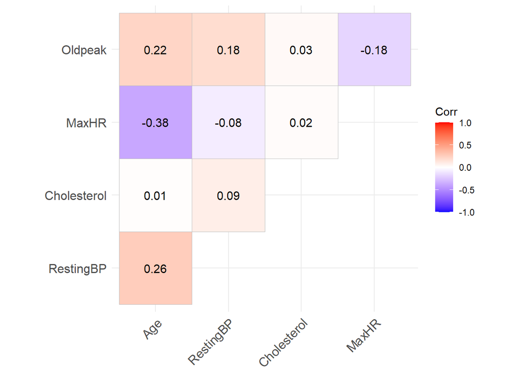

```r
ggcorrplot(cor(training%>%select(where(is.numeric)),use="pairwise.complete.obs"),show.diag = F,lab = T,type = "upper")
```

Visualizziamo tramite boxplot le distribuzioni delle variabili, in modo da osservare anche se sono presenti outliers.

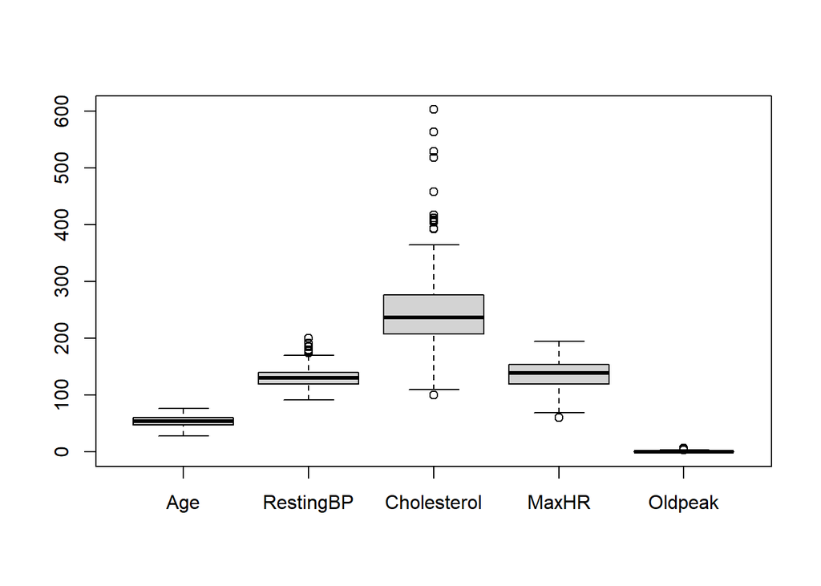

```r
boxplot(training%>%select(where(is.numeric)))
```

Le variabili assumono chiaramente valori in range diversi.

## Standardizzazione

Abbiamo visto che le variabili indipendenti possiedono range di variazione differenti, operiamo perciò una standardizzazione. Come indice di posizione optiamo per la media aritmetica mentre lo scarto quadratico medio sarà il nostro indice di variabilità; ovviamente entrambe le misure verranno calcolate sul training set per poi essere utilizzate nella fase di standardizzazione su tutto il dataset.

```r
means=colMeans(training%>%select(where(is.numeric)),na.rm=T)
variances=apply(training%>%select(where(is.numeric)),2,function(x){var(x,na.rm=T)})
training_non_stand=training
validation_non_stand=validation
test_non_stand=test
heart_non_stand=heart
training[,c("Age","RestingBP","Cholesterol","MaxHR","Oldpeak")]=scale(training%>%select(where(is.numeric)),center=means,scale = sqrt(variances))
validation[,c("Age","RestingBP","Cholesterol","MaxHR","Oldpeak")]=scale(validation%>%select(where(is.numeric)),center=means,scale = sqrt(variances))
test[,c("Age","RestingBP","Cholesterol","MaxHR","Oldpeak")]=scale(test%>%select(where(is.numeric)),center=means,scale=sqrt(variances))
heart[,c("Age","RestingBP","Cholesterol","MaxHR","Oldpeak")]=scale(heart%>%select(where(is.numeric)),center=means,scale=sqrt(variances))
training_and_valid=rbind(training,validation)
```

## Imputazione

Proviamo diversi metodi d’imputazione messi a disposizione dal pacchetto *mice*, per il trattamento dei missing values nella variabile **Cholesterol**.

```r
matrix=matrix(1,nrow=12,ncol=12)
matrix[,12]=0
tempDatapmm=mice(training_and_valid,m=1,maxit=50,meth='pmm',seed=1,predictorMatrix = matrix,printFlag = F)
tempDatamean=mice(training_and_valid,m=1,maxit=50,meth='mean',seed=1,predictorMatrix = matrix,printFlag = F)
tempDatanorm=mice(training_and_valid,m=1,maxit=50,meth='norm',seed=1,predictorMatrix = matrix,printFlag = F)
tempDatanorm.nob=mice(training_and_valid,m=1,maxit=50,meth='norm.nob',seed=1,predictorMatrix = matrix,printFlag = F)
tempDatanormpred=mice(training_and_valid,m=1,maxit=50,meth='norm.predict',seed=1,predictorMatrix = matrix,printFlag = F)
tempDataLasso=mice(training_and_valid,m=1,maxit=50,meth='lasso.norm',seed=1,predictorMatrix = matrix,printFlag = F)
tempDatacart=mice(training_and_valid,m=1,maxit=50,meth='cart',seed=1,predictorMatrix = matrix,printFlag = F)
mice_imputed=data.frame(
  original = training_and_valid$Cholesterol,
  imputed_pmm = complete(tempDatapmm)$Cholesterol,
  imputed_cart = complete(tempDatacart)$Cholesterol,
  imputed_lasso = complete(tempDataLasso)$Cholesterol,
  imputed_mean = complete(tempDatamean)$Cholesterol,
  imputed_norm = complete(tempDatanorm)$Cholesterol,
  imputed_normpred = complete(tempDatanormpred)$Cholesterol
)
```

Adesso dovremo scegliere il metodo migliore, selezionando quello che più rispetta la distribuzione originale della variabile **Cholesterol**. Il confronto avverrà tramite istogrammi.

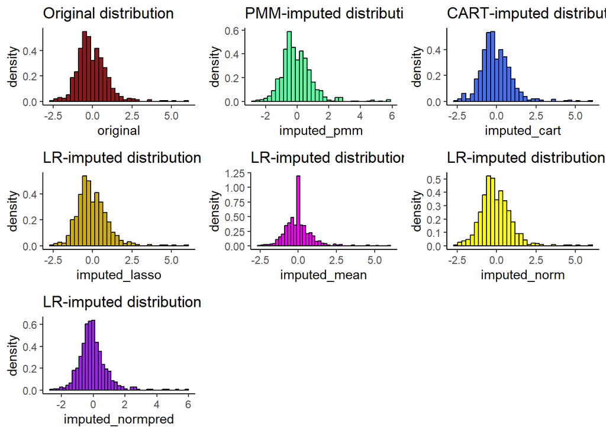

```r
bins_FD=round(apply(mice_imputed,2,function(x) (max(x,na.rm = T)-min(x,na.rm = T))/(2*IQR(x,na.rm = T))*length(x)^(1/3)))
mice_original=ggplot(mice_imputed, aes(x = original,y=after_stat(density))) +
  geom_histogram(fill = "firebrick4", color = "black", position = "identity",bins=bins_FD[1]) +
  ggtitle("Original distribution") +
  theme_classic()
mice_pmm= ggplot(mice_imputed, aes(x = imputed_pmm,y=after_stat(density))) +
  geom_histogram(fill = "seagreen1", color = "black", position = "identity",bins=bins_FD[2]) +
  ggtitle("PMM-imputed distribution") +
  theme_classic()
mice_cart = ggplot(mice_imputed, aes(x = imputed_cart,y=after_stat(density))) +
  geom_histogram(fill = "royalblue2", color = "black", position = "identity",bins=bins_FD[3]) +
  ggtitle("CART-imputed distribution") +
  theme_classic()
mice_lasso = ggplot(mice_imputed, aes(x = imputed_lasso,y=after_stat(density))) +
  geom_histogram(fill = "gold3", color = "black", position = "identity",bins=bins_FD[4]) +
  ggtitle("LR-imputed distribution") +
  theme_classic()
mice_mean = ggplot(mice_imputed, aes(x = imputed_mean,y=after_stat(density))) +
  geom_histogram(fill = "magenta", color = "black", position = "identity",bins=bins_FD[5]) +
  ggtitle("LR-imputed distribution") +
  theme_classic()
mice_norm = ggplot(mice_imputed, aes(x = imputed_norm,y=after_stat(density))) +
  geom_histogram(fill = "yellow", color = "black", position = "identity",bins=bins_FD[6]) +
  ggtitle("LR-imputed distribution") +
  theme_classic()
mice_normpred = ggplot(mice_imputed, aes(x = imputed_normpred,y=after_stat(density))) +
  geom_histogram(fill = "purple", color = "black", position = "identity",bins=bins_FD[7]) +
  ggtitle("LR-imputed distribution") +
  theme_classic()
plot_grid(mice_original,mice_pmm,mice_cart,mice_lasso,mice_mean,mice_norm,mice_normpred)
```

Non essendo presente un metodo chiaramente superiore rispetto agli altri, scegliamo i tre metodi migliori e operiamo un confronto ulteriore attraverso il *densityplot* .

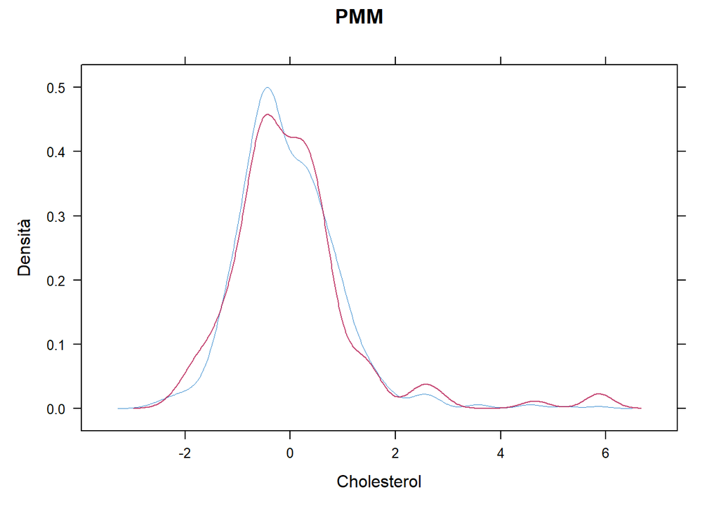

```r
dens_pmm=densityplot(tempDatapmm,thicker = 0.7,main="PMM")
dens_Lasso=densityplot(tempDataLasso,thicker = 0.7,main="Lasso")
dens_cart=densityplot(tempDatacart,thicker = 0.7,main="Cart")
plot(dens_pmm)
```

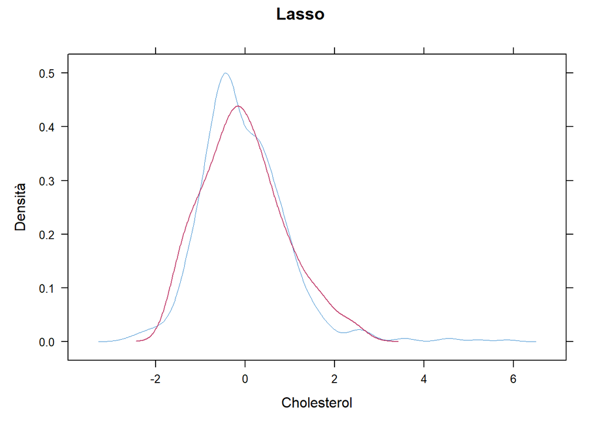

```r
plot(dens_Lasso)
```

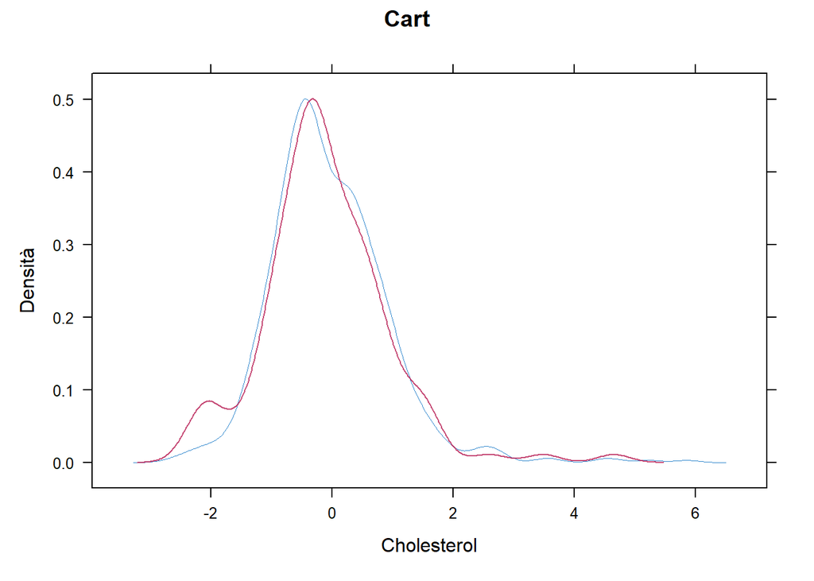

```r
plot(dens_cart)
```

Il metodo più ragionevole sembra il *cart*, passiamo all’imputazione su tutto il dataset.

```r
training_original=training
validation_original=validation
heart_imputed=mice(heart,predictorMatrix = matrix,meth="cart",m=1,printFlag = F,maxit = 50,ignore=c(1:nrow(heart))%in%test.index)
test$Cholesterol=complete(heart_imputed)[test.index,]
training=inner_join(training_original,complete(heart_imputed),join_by(Age,Sex,ChestPainType,RestingBP,FastingBS,RestingECG,MaxHR,Oldpeak,ExerciseAngina,HeartDisease,ST_Slope))%>%
  mutate(Cholesterol=Cholesterol.y)%>%
  select(!contains("."))
validation=inner_join(validation_original,complete(heart_imputed),join_by(Age,Sex,ChestPainType,RestingBP,FastingBS,RestingECG,MaxHR,Oldpeak,ExerciseAngina,HeartDisease,ST_Slope))%>%
  mutate(Cholesterol=Cholesterol.y)%>%
  select(!contains("."))
```

## Verifica assunzioni

In questa sezione verificheremo la possibilità di applicare tecniche come l’analisi discriminante lineare (*LDA*) e l’analisi discriminante quadratica (*QDA*). Le suddette tecniche presuppongono una distribuzione normale delle covariate condizionatamente alle modalità dellla target.

Verifichiamo graficamente se le variabili abbiano covarianza in comune.

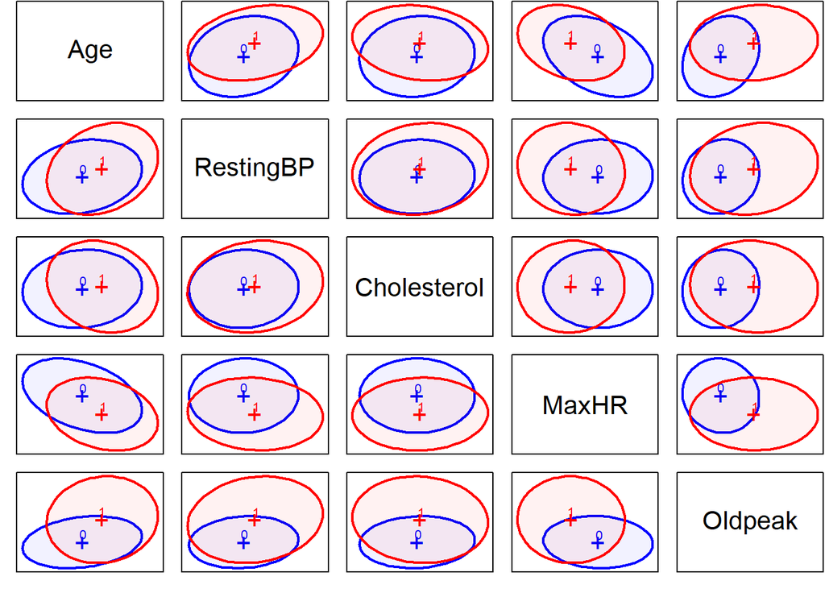

```r
covEllipses(training%>%select(where(is.numeric)),
            factor(training$HeartDisease),
            fill = TRUE,
            pooled = FALSE,
            col = c("blue", "red"),
            variables=c("Age","RestingBP","Cholesterol","MaxHR","Oldpeak"),
            fill.alpha = 0.05)
```

Un’addizionale indicazione viene fornita dai boxplot condizionati.

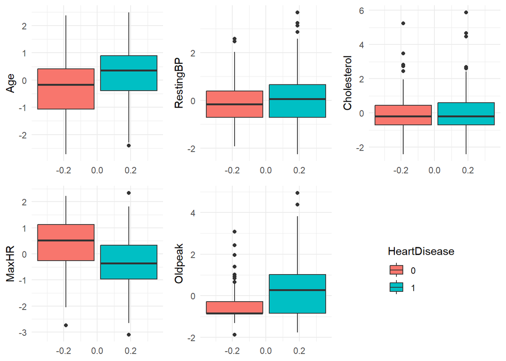

```r
box1=ggplot(training,aes(y=Age,fill=HeartDisease))+
  geom_boxplot(show.legend = F)+
  theme_minimal()
box2=ggplot(training,aes(y=RestingBP,fill=HeartDisease))+
  geom_boxplot(show.legend = F)+
  theme_minimal()
box3=ggplot(training,aes(y=Cholesterol,fill=HeartDisease))+
  geom_boxplot(show.legend = F)+
  theme_minimal()
box4=ggplot(training,aes(y=MaxHR,fill=HeartDisease))+
  geom_boxplot(show.legend = F)+
  theme_minimal()
box5=ggplot(training,aes(y=Oldpeak,fill=HeartDisease))+
  geom_boxplot(show.legend = F)+
  theme_minimal()
box_legend=get_legend(ggplot(training,aes(y=Age,fill=HeartDisease))+
                        geom_boxplot(show.legend = T)+
                        theme_minimal())
plot_grid(box1,box2,box3,box4,box5,box_legend,ncol=3)
```

Le informazioni date dai boxplot sono piuttosto esigue, perciò passiamo a grafici più accurati.

Al fine di verificare la normalità condizionata delle variabili usiamo in primo luogo dei *qqplot*.

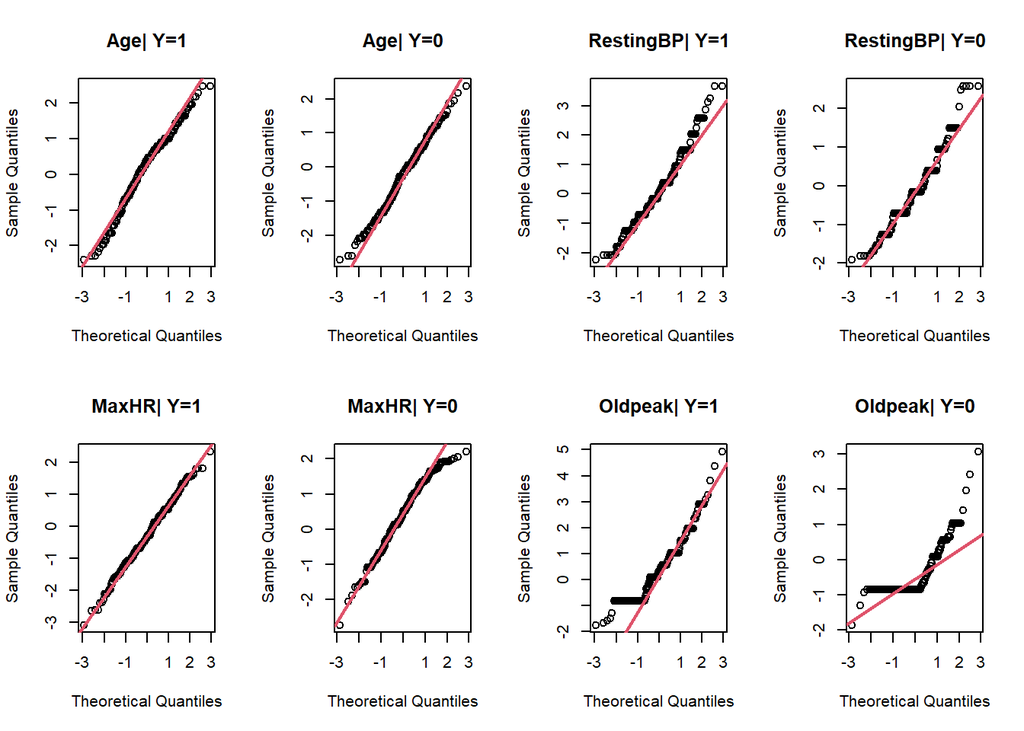

```r
par(mfrow=c(2,4))
qqnorm(training$Age[training$HeartDisease==1],main = "Age| Y=1");qqline(training$Age[training$HeartDisease==1],col=2,lwd=2)
qqnorm(training$Age[training$HeartDisease==0],main = "Age| Y=0");qqline(training$Age[training$HeartDisease==0],col=2,lwd=2)
qqnorm(training$RestingBP[training$HeartDisease==1],main = "RestingBP| Y=1");qqline(training$RestingBP[training$HeartDisease==1],col=2,lwd=2)
qqnorm(training$RestingBP[training$HeartDisease==0],main = "RestingBP| Y=0");qqline(training$RestingBP[training$HeartDisease==0],col=2,lwd=2)
qqnorm(training$MaxHR[training$HeartDisease==1],main = "MaxHR| Y=1");qqline(training$MaxHR[training$HeartDisease==1],col=2,lwd=2)
qqnorm(training$MaxHR[training$HeartDisease==0],main = "MaxHR| Y=0");qqline(training$MaxHR[training$HeartDisease==0],col=2,lwd=2)
qqnorm(training$Oldpeak[training$HeartDisease==1],main = "Oldpeak| Y=1");qqline(training$Oldpeak[training$HeartDisease==1],col=2,lwd=2)
qqnorm(training$Oldpeak[training$HeartDisease==0],main = "Oldpeak| Y=0");qqline(training$Oldpeak[training$HeartDisease==0],col=2,lwd=2)
```

```r
par(mfrow=c(1,1))
```

Dai qqplots possiamo notare come alcune variabili sembrerebbero distribuirsi normalmente, al contrario altre sono lontane dalla normalità. Per risultati oggettivi facciamo uso di alcuni test, quali il *Kolmogorov-Smirnov* e quello di *Shapiro*.

```r
apply(training%>%filter(HeartDisease==1)%>%select(where(is.numeric)),2,function(x) ks.test(x,y="dnorm")$p.value)
```

```
##         Age   RestingBP       MaxHR     Oldpeak Cholesterol
##           0           0           0           0           0
```

```r
apply(training%>%filter(HeartDisease==1)%>%select(where(is.numeric)),2,function(x) shapiro.test(x)$p.value)
```

```
##          Age    RestingBP        MaxHR      Oldpeak  Cholesterol
## 3.481059e-04 5.919100e-05 7.655581e-01 1.145152e-10 1.419618e-13
```

```r
apply(training%>%filter(HeartDisease==0)%>%select(where(is.numeric)),2,function(x) ks.test(x,y="dnorm")$p.value)
```

```
##         Age   RestingBP       MaxHR     Oldpeak Cholesterol
##           0           0           0           0           0
```

```r
apply(training%>%filter(HeartDisease==0)%>%select(where(is.numeric)),2,function(x) shapiro.test(x)$p.value)
```

```
##          Age    RestingBP        MaxHR      Oldpeak  Cholesterol
## 2.189069e-01 1.764890e-06 1.792072e-03 5.761538e-21 2.095663e-09
```

Ispezioniamo le densità delle variabili indipendenti condizionate alla target.

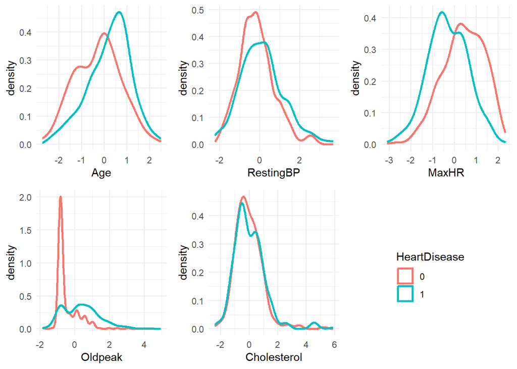

```r
age_dens=ggplot(training,aes(x=Age,col=HeartDisease))+
  geom_density(linewidth=1,show.legend = F)+
  theme_minimal()
resting_dens=ggplot(training,aes(x=RestingBP,col=HeartDisease))+
  geom_density(linewidth=1,show.legend = F)+
  theme_minimal()
maxhr_dens=ggplot(training,aes(x=MaxHR,col=HeartDisease))+
  geom_density(linewidth=1,show.legend = F)+
  theme_minimal()
oldpeak_dens=ggplot(training,aes(x=Oldpeak,col=HeartDisease))+
  geom_density(linewidth=1,show.legend = F)+
  theme_minimal()
choles_dens=ggplot(training,aes(x=Cholesterol,col=HeartDisease))+
  geom_density(linewidth=1,show.legend = F)+
  theme_minimal()
legend=get_legend(ggplot(training,aes(x=Age,col=HeartDisease))+
  geom_density(linewidth=1)+
  theme_minimal())
plot_grid(age_dens,resting_dens,maxhr_dens,oldpeak_dens,choles_dens,legend,ncol=3)
```

Le condizionate sono chiaramente multimodali indi per cui l’assunzione di normalità è insostenibile.

## Modeling

Siamo nel cuore dell’analisi. Prendiamo in considerazione diversi modelli, per ognuno di questi avremo una fase di training del classificatore e una fase di validation atta a selezionare il modello migliore tra questi. La metrica di valutazione più consona al problema in questione è la *Sensitivity*, che indica la percentuale di malati correttamente classificati.

Questa viene preferita all’*Accuracy* perchè in un contesto medico l’individuazione corretta della malattia assume una priorità maggiore. Al fine di mantenere una visione d’insieme della qualità previsionale le esaminiamo entrambe. I due modelli con le performance previsionali più elevate verranno condotti alla fase di testing.

### MDA

L’Analisi Discriminante Lineare e Quadratica presuppongono una mistura Gaussiana, ovvero che le covariate si distribuiscano normalmente condizionatamente alle modalità della target.

La Mixtures Discriminant Analysis (*MDA*) è un metodo di classificazione che estende l’approccio di *LDA* e *QDA*, assumendo che le distribuzioni condizionate delle covariate siano a loro volta misture di Normali.

Nel nostro caso è possibile notare che quasi nessuna variabile rispetti le assunzioni di *LDA* e *QDA*. Possiamo presumere che ciò non valga per l’*MDA* data la multimodalità delle distribuzioni condizionate. L’ *MDA* tenta di stimare i parametri delle misture interne e di quella che le contiene; a fini classificatori anch’essa fa ricorso alle probabilità a posteriori.

La complessità del modello assunto implica un elevato numero di parametri da stimare. Per suddetto motivo, solitamente s’impongono forti assunzioni sulle componenti delle misture all’interno di ogni covariata, come l’omoschedasticità.

```r
mod_mda=MclustDA(training[,-12]%>%select(where(is.numeric)),class = training$HeartDisease,G=c(1:9))
pred_mda=predict(mod_mda,validation[,-12]%>%select(where(is.numeric)))
confmat_mda=table(pred_mda$classification,validation$HeartDisease)
metriche(confmat_mda)
```

```
##    Accuracy Sensitivity
##   0.7213115   0.7010309
```

Per quantificare le performance di questo modello, necessitiamo di un confronto con i successivi.

### Classification Trees

```r
set.seed(8)
tree.Heart = tree(HeartDisease ~.,data=training_original)
summary(tree.Heart)
```

```
##
## Classification tree:
## tree(formula = HeartDisease ~ ., data = training_original)
## Variables actually used in tree construction:
##  [1] "ST_Slope"       "ChestPainType"  "Cholesterol"    "RestingECG"
##  [5] "Oldpeak"        "MaxHR"          "Age"            "ExerciseAngina"
##  [9] "Sex"            "RestingBP"
## Number of terminal nodes:  15
## Residual mean deviance:  0.5842 = 252.4 / 432
## Misclassification error rate: 0.1298 = 58 / 447
```

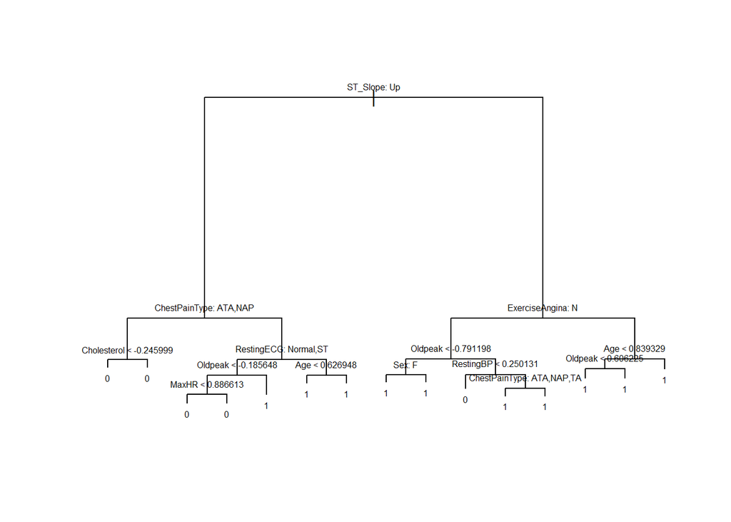

```r
plot(tree.Heart)
text(tree.Heart,cex=0.5,pretty = 0)
```

La variabile *ST_Slope* crea la prima diramazione, da ciò deduciamo che è molto rilevante ai fini classificatori.

```r
tree.pred = predict(tree.Heart , validation_original , type = "class")
confmat_tree=table(tree.pred , validation_original$HeartDisease)
metriche(confmat_tree)
```

```
##    Accuracy Sensitivity
##   0.7978142   0.7938144
```

Possiamo notare un miglioramento per entrambe le metriche di valutazione.

### Pruning

Gli alberi di classificazione tendono notoriamente ad essere troppo complessi,si applica quindi una tecnica chiamata *pruning* atta alla semplificazione dell’albero pre-esistente. In questo ambito optiamo per il *Cost complexity pruning*.

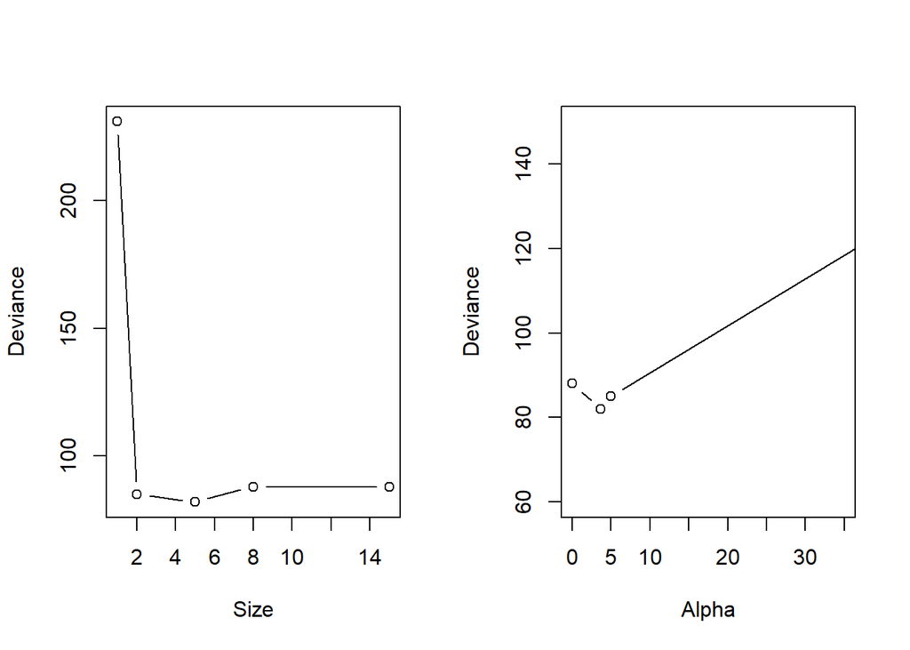

```r
cv.Heart = cv.tree(tree.Heart , FUN = prune.misclass)
par(mfrow = c(1, 2))
plot(cv.Heart$size , cv.Heart$dev,ylab="Deviance",xlab="Size", type = "b")
plot(cv.Heart$k, cv.Heart$dev,ylab="Deviance",xlab="Alpha",ylim=c(60,150),xlim=c(0,35) ,type = "b")
```

```r
par(mfrow = c(1, 1))
```

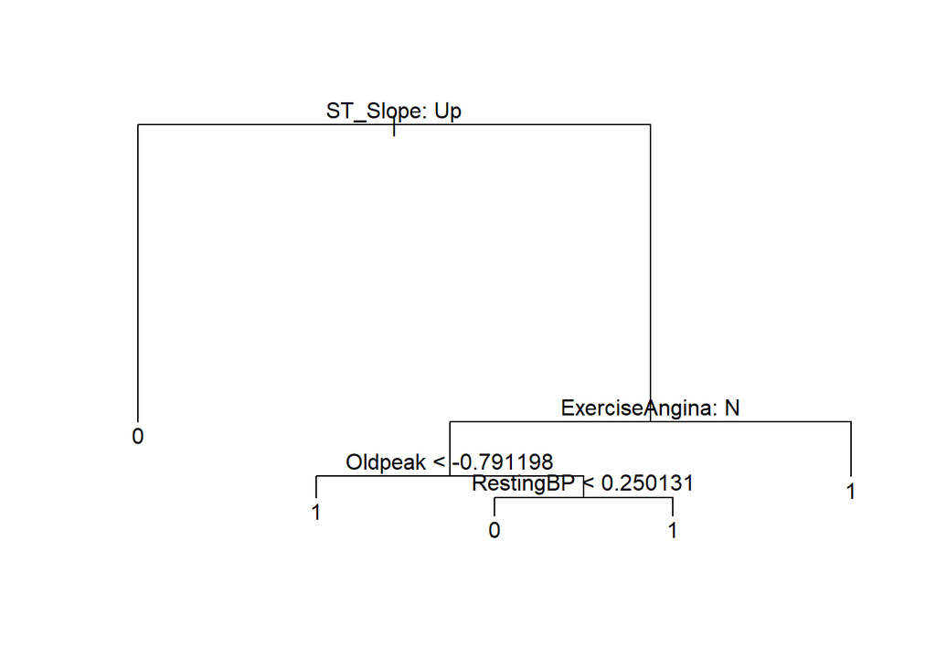

```r
best_size=cv.Heart$size[which.min(cv.Heart$dev)]
prune.Heart = prune.misclass(tree.Heart , best = best_size)

plot(prune.Heart)
text(prune.Heart , pretty = 0)
```

```r
tree.pred_pruning = predict(prune.Heart , validation_original , type = "class")
confmat_pruning=table(tree.pred_pruning , validation_original$HeartDisease)
metriche(confmat_pruning)
```

```
##    Accuracy Sensitivity
##   0.7978142   0.7319588
```

A differenza di quanto ci saremmo aspettati le previsioni non migliorano in termini di *Sensitivity*.

### K-NN

Un ulteriore metodo di classificazione è il K-NN. Per il calcolo delle distanza tra osservazioni si utilizza la distanza Euclidea per questo motivo codifichiamo le variabili qualitative utilizzando delle *dummies*.

```r
train_dummy=training%>%mutate(Sex=ifelse(Sex=="M",1,0),ChestPainTypeATA=ifelse(ChestPainType=="ATA",1,0),ChestPainTypeNAP=ifelse(ChestPainType=="NAP",1,0),
                           ChestPainTypeTA=ifelse(ChestPainType=="TA",1,0),RestingECGNormal=ifelse(RestingECG=="Normal",1,0),
                           RestingECGST=ifelse(RestingECG=="ST",1,0),ExerciseAngina=ifelse(ExerciseAngina=="Y",1,0),
                           ST_SlopeFlat=ifelse(ST_Slope=="Flat",1,0),ST_SlopeUp=ifelse(ST_Slope=="Up",1,0))
train_dummy=train_dummy[,-c(3,6,10)]
valid_dummy=validation%>%mutate(Sex=ifelse(Sex=="M",1,0),ChestPainTypeATA=ifelse(ChestPainType=="ATA",1,0),ChestPainTypeNAP=ifelse(ChestPainType=="NAP",1,0),
                                ChestPainTypeTA=ifelse(ChestPainType=="TA",1,0),RestingECGNormal=ifelse(RestingECG=="Normal",1,0),
                                RestingECGST=ifelse(RestingECG=="ST",1,0),ExerciseAngina=ifelse(ExerciseAngina=="Y",1,0),
                                ST_SlopeFlat=ifelse(ST_Slope=="Flat",1,0),ST_SlopeUp=ifelse(ST_Slope=="Up",1,0))
valid_dummy=valid_dummy[,-c(3,6,10)]

ks=seq(1,21,by=2)
knn_cv=apply(as.matrix(ks),1,function(x){mod_knn=knn(train_dummy[,-8],k=x,test=valid_dummy[,-8],cl=train_dummy$HeartDisease)
confmat_knn_cv=table(mod_knn,valid_dummy$HeartDisease)
c(x,confmat_knn_cv[2,2]/sum(confmat_knn_cv[,2]),sum(diag(confmat_knn_cv))/nrow(validation))})
```

La scelta dell’iperparametro K avviene attraverso la cross-validation.

```r
k_cv=knn_cv[1,which.max(knn_cv[2,])]
mod_knn_cv=knn(train_dummy[,-8],k=k_cv,test=valid_dummy[,-8],cl=training$HeartDisease)
confmat_knn=table(mod_knn_cv,validation$HeartDisease)
```

```r
metriche(confmat_knn)
```

```
##    Accuracy Sensitivity
##   0.8743169   0.8762887
```

Le due metriche di valutazione prese in considerazione mostrano risultati eccellenti.

### Logistic Regression

In questa sezione utilizzeremo, come metodo di classificazione, la regressione logistica.

Iniziamo a valutare una regressione logistica includendo tutte le variabili a disposizione.

```r
logistic_mod=glm(HeartDisease~. ,data = training, family="binomial")
summary(logistic_mod)
```

```
##
## Call:
## glm(formula = HeartDisease ~ ., family = "binomial", data = training)
##
## Coefficients:
##                  Estimate Std. Error z value Pr(>|z|)
## (Intercept)      -0.58025    0.64808  -0.895 0.370612
## Age               0.12469    0.15077   0.827 0.408250
## SexM              1.44424    0.34662   4.167 3.09e-05 ***
## ChestPainTypeATA -1.70506    0.40559  -4.204 2.62e-05 ***
## ChestPainTypeNAP -1.89691    0.34417  -5.512 3.56e-08 ***
## ChestPainTypeTA  -1.25037    0.51106  -2.447 0.014420 *
## RestingBP         0.12333    0.14038   0.879 0.379671
## FastingBS1        1.53934    0.33631   4.577 4.71e-06 ***
## RestingECGNormal -0.27629    0.32763  -0.843 0.399059
## RestingECGST     -0.37777    0.42794  -0.883 0.377363
## MaxHR            -0.05102    0.15721  -0.325 0.745543
## ExerciseAnginaY   1.08680    0.30028   3.619 0.000295 ***
## Oldpeak           0.35203    0.15817   2.226 0.026037 *
## ST_SlopeFlat      1.03106    0.55956   1.843 0.065384 .
## ST_SlopeUp       -1.20726    0.59350  -2.034 0.041939 *
## Cholesterol       0.00913    0.12664   0.072 0.942524
## ---
## Signif. codes:  0 '***' 0.001 '**' 0.01 '*' 0.05 '.' 0.1 ' ' 1
##
## (Dispersion parameter for binomial family taken to be 1)
##
##     Null deviance: 757.32  on 551  degrees of freedom
## Residual deviance: 382.13  on 536  degrees of freedom
## AIC: 414.13
##
## Number of Fisher Scoring iterations: 5
```

Valutiamo ora la regressione logistica per *step* secondo il criterio dell’ *AIC*.

```r
step_logistic_mod=step(logistic_mod, direction = "both", trace = F)
summary(step_logistic_mod)
```

```
##
## Call:
## glm(formula = HeartDisease ~ Sex + ChestPainType + FastingBS +
##     ExerciseAngina + Oldpeak + ST_Slope, family = "binomial",
##     data = training)
##
## Coefficients:
##                  Estimate Std. Error z value Pr(>|z|)
## (Intercept)       -0.7655     0.6120  -1.251   0.2110
## SexM               1.3762     0.3401   4.046 5.20e-05 ***
## ChestPainTypeATA  -1.7261     0.3978  -4.339 1.43e-05 ***
## ChestPainTypeNAP  -1.8586     0.3369  -5.517 3.46e-08 ***
## ChestPainTypeTA   -1.1331     0.5016  -2.259   0.0239 *
## FastingBS1         1.5230     0.3308   4.604 4.13e-06 ***
## ExerciseAnginaY    1.1552     0.2859   4.040 5.34e-05 ***
## Oldpeak            0.3746     0.1540   2.432   0.0150 *
## ST_SlopeFlat       1.0293     0.5524   1.864   0.0624 .
## ST_SlopeUp        -1.2552     0.5808  -2.161   0.0307 *
## ---
## Signif. codes:  0 '***' 0.001 '**' 0.01 '*' 0.05 '.' 0.1 ' ' 1
##
## (Dispersion parameter for binomial family taken to be 1)
##
##     Null deviance: 757.32  on 551  degrees of freedom
## Residual deviance: 385.67  on 542  degrees of freedom
## AIC: 405.67
##
## Number of Fisher Scoring iterations: 5
```

```r
anova(step_logistic_mod,test = "Chisq")
```

```
## Analysis of Deviance Table
##
## Model: binomial, link: logit
##
## Response: HeartDisease
##
## Terms added sequentially (first to last)
##
##
##                Df Deviance Resid. Df Resid. Dev  Pr(>Chi)
## NULL                             551     757.32
## Sex             1   47.523       550     709.80 5.437e-12 ***
## ChestPainType   3  141.032       547     568.77 < 2.2e-16 ***
## FastingBS       1   25.878       546     542.89 3.637e-07 ***
## ExerciseAngina  1   62.197       545     480.70 3.108e-15 ***
## Oldpeak         1   30.422       544     450.27 3.475e-08 ***
## ST_Slope        2   64.601       542     385.67 9.378e-15 ***
## ---
## Signif. codes:  0 '***' 0.001 '**' 0.01 '*' 0.05 '.' 0.1 ' ' 1
```

Controlliamo la presenza di outliers e influence points

```r
outlierTest(step_logistic_mod)
```

```
## No Studentized residuals with Bonferroni p < 0.05
## Largest |rstudent|:
##     rstudent unadjusted p-value Bonferroni p
## 21 -2.694785          0.0070434           NA
```

Non si rileva la presenza di outliers

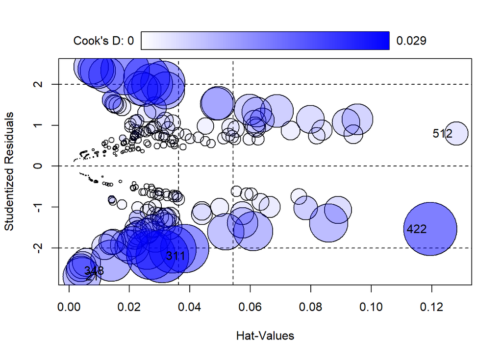

```r
infplot=influencePlot(step_logistic_mod)
```

Proviamo a togliere i punti influenti evidenzati dal grafico,tenendo presente un modello di regressione iniziale contenente tutte le variabili.

```r
obs_inf=as.numeric(rownames(infplot))
logistic_mod_no_inf=glm(HeartDisease~. ,data = training[-obs_inf,], family="binomial")
summary(logistic_mod_no_inf)
```

```
##
## Call:
## glm(formula = HeartDisease ~ ., family = "binomial", data = training[-obs_inf,
##     ])
##
## Coefficients:
##                  Estimate Std. Error z value Pr(>|z|)
## (Intercept)      -0.30181    0.72068  -0.419 0.675375
## Age               0.12077    0.15484   0.780 0.435423
## SexM              1.59413    0.36088   4.417 9.99e-06 ***
## ChestPainTypeATA -1.75052    0.41453  -4.223 2.41e-05 ***
## ChestPainTypeNAP -2.03019    0.35793  -5.672 1.41e-08 ***
## ChestPainTypeTA  -1.18634    0.52840  -2.245 0.024759 *
## RestingBP         0.15403    0.14705   1.047 0.294908
## FastingBS1        1.58212    0.35030   4.516 6.29e-06 ***
## RestingECGNormal -0.24244    0.33708  -0.719 0.471997
## RestingECGST     -0.41805    0.44706  -0.935 0.349729
## MaxHR            -0.10468    0.16349  -0.640 0.522008
## ExerciseAnginaY   1.07210    0.31107   3.446 0.000568 ***
## Oldpeak           0.44338    0.17387   2.550 0.010769 *
## ST_SlopeFlat      0.71780    0.63037   1.139 0.254833
## ST_SlopeUp       -1.54978    0.65402  -2.370 0.017806 *
## Cholesterol       0.09341    0.13264   0.704 0.481293
## ---
## Signif. codes:  0 '***' 0.001 '**' 0.01 '*' 0.05 '.' 0.1 ' ' 1
##
## (Dispersion parameter for binomial family taken to be 1)
##
##     Null deviance: 749.58  on 546  degrees of freedom
## Residual deviance: 359.18  on 531  degrees of freedom
## AIC: 391.18
##
## Number of Fisher Scoring iterations: 6
```

Notiamo un miglioramento in termini di *AIC* rispetto ai due modelli precedenti.

Come fatto in precedenza applichiamo al modello senza punti influenti una selezione *stepwise*.

```r
step_logistic_mod_no_inf=step(logistic_mod_no_inf, direction = "both", trace = F)
summary(step_logistic_mod_no_inf)
```

```
##
## Call:
## glm(formula = HeartDisease ~ Sex + ChestPainType + FastingBS +
##     ExerciseAngina + Oldpeak + ST_Slope, family = "binomial",
##     data = training[-obs_inf, ])
##
## Coefficients:
##                  Estimate Std. Error z value Pr(>|z|)
## (Intercept)       -0.5321     0.6804  -0.782  0.43420
## SexM               1.5021     0.3534   4.250 2.14e-05 ***
## ChestPainTypeATA  -1.7695     0.4058  -4.361 1.30e-05 ***
## ChestPainTypeNAP  -1.9839     0.3491  -5.683 1.32e-08 ***
## ChestPainTypeTA   -1.0858     0.5235  -2.074  0.03806 *
## FastingBS1         1.5521     0.3435   4.518 6.24e-06 ***
## ExerciseAnginaY    1.1813     0.2954   3.999 6.37e-05 ***
## Oldpeak            0.4379     0.1696   2.581  0.00985 **
## ST_SlopeFlat       0.7945     0.6216   1.278  0.20118
## ST_SlopeUp        -1.5678     0.6424  -2.441  0.01467 *
## ---
## Signif. codes:  0 '***' 0.001 '**' 0.01 '*' 0.05 '.' 0.1 ' ' 1
##
## (Dispersion parameter for binomial family taken to be 1)
##
##     Null deviance: 749.58  on 546  degrees of freedom
## Residual deviance: 363.82  on 537  degrees of freedom
## AIC: 383.82
##
## Number of Fisher Scoring iterations: 6
```

```r
anova(step_logistic_mod_no_inf,test = "Chisq")
```

```
## Analysis of Deviance Table
##
## Model: binomial, link: logit
##
## Response: HeartDisease
##
## Terms added sequentially (first to last)
##
##
##                Df Deviance Resid. Df Resid. Dev  Pr(>Chi)
## NULL                             546     749.58
## Sex             1   50.473       545     699.10 1.208e-12 ***
## ChestPainType   3  143.734       542     555.37 < 2.2e-16 ***
## FastingBS       1   26.597       541     528.77 2.506e-07 ***
## ExerciseAngina  1   64.373       540     464.40 1.030e-15 ***
## Oldpeak         1   35.775       539     428.62 2.214e-09 ***
## ST_Slope        2   64.802       537     363.82 8.481e-15 ***
## ---
## Signif. codes:  0 '***' 0.001 '**' 0.01 '*' 0.05 '.' 0.1 ' ' 1
```

Osserviamo un ulteriore riduzione dell’*AIC*.

Confrontiamo ora il comportamento dei 4 modelli di regressione logistica trovati secondo le metriche di valutazione scelte.

```r
step_logistic_mod_no_inf_pred = round(predict(step_logistic_mod_no_inf, validation, type = "response"),0)
confmat_step_logistic_mod_no_inf=table(step_logistic_mod_no_inf_pred , validation$HeartDisease)
```

Regressione stepwise senza influenti

```r
metriche(confmat_step_logistic_mod_no_inf)
```

```
##    Accuracy Sensitivity
##   0.8797814   0.8762887
```

```r
step_logistic_mod_pred = round(predict(step_logistic_mod, validation, type = "response"),0)
confmat_step_logistic_mod=table(step_logistic_mod_pred , validation$HeartDisease)
```

Regressione stepwise

```r
metriche(confmat_step_logistic_mod)
```

```
##    Accuracy Sensitivity
##   0.8743169   0.8659794
```

```r
logistic_mod_pred = round(predict(logistic_mod, validation, type = "response"),0)
confmat_logistic_mod=table(logistic_mod_pred , validation$HeartDisease)
```

Regressione

```r
metriche(confmat_logistic_mod)
```

```
##    Accuracy Sensitivity
##   0.8743169   0.8556701
```

```r
logistic_mod_no_inf_pred = round(predict(logistic_mod_no_inf, validation, type = "response"),0)
confmat_logistic_mod_no_inf=table(logistic_mod_no_inf_pred , validation$HeartDisease)
```

Regressione senza influenti

```r
metriche(confmat_logistic_mod_no_inf)
```

```
##    Accuracy Sensitivity
##   0.8797814   0.8659794
```

La regressione logistica risulta altamente efficace in questo contesto,la rimozione dei punti influenti non ha grosso impatto sulle metriche.Preferiremo il modello *stepwise* perchè contenente un numero inferiore di features e quindi meno complesso.

#### Diagnostica del Modello di regressione

Per la diagnostica teniamo in considerazione il modello di regressione con livelli di performance migliore, ovvero quello con criterio stepwise senza punti influenti.

Andiamo a plottare l’andamento della variabile target, opportunamente trasformata (logit), con quello delle covariate numeriche. (le variabili qualitative sono insensate da rappresentare).

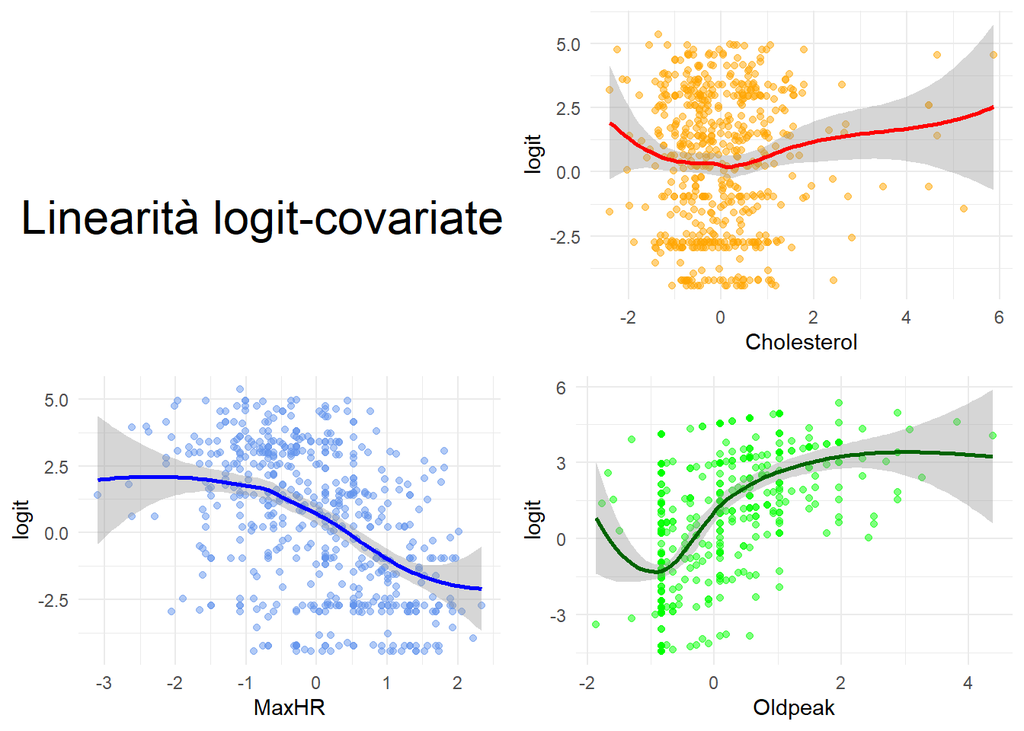

```r
probabilities = predict(step_logistic_mod_no_inf, type = "response")
predictors = c("Sex","ChestPainType","Cholesterol","FastingBS","MaxHR","ExerciseAngina","Oldpeak","ST_Slope")
logit_training=training[-obs_inf,]%>%
  select(all_of(predictors))
logit_training = logit_training %>%
  mutate(logit = log(probabilities/(1-probabilities)))

text = paste("\n Linearità logit-covariate")

plot_grid(ggplot() +
  annotate("text", x = 4, y = 25, size=8, label = text) +
  theme_void(),
  ggplot(data=logit_training, aes(Cholesterol,logit))+
  geom_point(alpha=.5,col="orange")+
  geom_smooth(method="loess",col="red")+
  theme_minimal(),
ggplot(data=logit_training, aes(MaxHR,logit))+
  geom_point(alpha=.5,col="cornflowerblue")+
  geom_smooth(method="loess",col="blue")+
  theme_minimal(),
ggplot(data=logit_training, aes(Oldpeak,logit))+
  geom_point(alpha=.5,col="green")+
  geom_smooth(method="loess",col="darkgreen")+
  theme_minimal()
)
```

## Selezione del modello

Confrontiamo ora le performance dei modelli presi in considerazione, per fare ciò utilizziamo metriche aggiuntive a quelle usate fin’ora per una miglior comprensione.

```r
confmats=list(mda=confmat_mda,tree=confmat_tree,pruning=confmat_pruning
              ,knn=confmat_knn,reglog=confmat_logistic_mod,reglognf=confmat_logistic_mod_no_inf,
              regstep=confmat_step_logistic_mod,regstepnf=confmat_step_logistic_mod_no_inf)
sapply(confmats,metriche)
```

```
##                   mda      tree   pruning       knn    reglog  reglognf
## Accuracy    0.7213115 0.7978142 0.7978142 0.8743169 0.8743169 0.8797814
## Sensitivity 0.7010309 0.7938144 0.7319588 0.8762887 0.8556701 0.8659794
##               regstep regstepnf
## Accuracy    0.8743169 0.8797814
## Sensitivity 0.8659794 0.8762887
```

F1-Score

```r
f1_score=function(tab){
  Recall=tab[2,2]/sum(tab[,2])
  Precision=tab[2,2]/sum(tab[2,])
  f1=2*Recall*Precision/(Recall+Precision)
  return(f1)
}
sapply(confmats,f1_score)
```

```
##       mda      tree   pruning       knn    reglog  reglognf   regstep regstepnf
## 0.7272727 0.8062827 0.7932961 0.8808290 0.8783069 0.8842105 0.8795812 0.8854167
```

Dalle metriche calcolate deduciamo che possiamo escludere dall’analisi sul test set l’albero, potato e non, e l’*MDA*. Per le regressioni logistiche l’*F1-Score* mostra anch’esso poca differenza tra loro.

Curva di ROC

```r
prediction_reglog=prediction(step_logistic_mod_pred,validation$HeartDisease)
performance(prediction_reglog,measure="auc")@y.values
```

```
## [[1]]
## [1] 0.8748502
```

```r
knn.pred=as.numeric(as.vector(mod_knn_cv))
prediction_knn=prediction(knn.pred,validation$HeartDisease)
performance(prediction_knn,measure="auc")@y.values
```

```
## [[1]]
## [1] 0.8741908
```

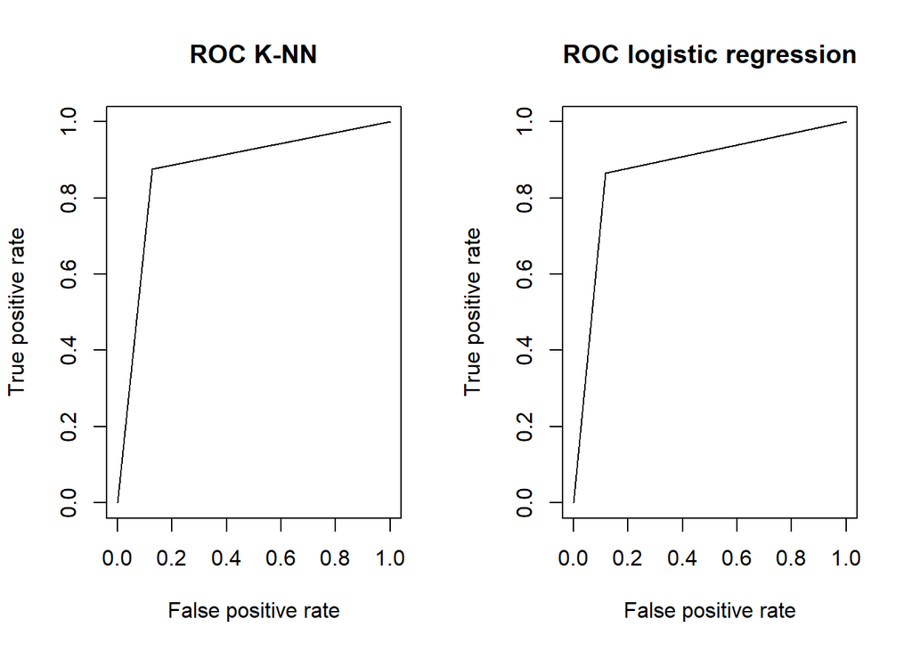

```r
par(mfrow=c(1,2))
plot(performance(prediction_knn,"tpr","fpr"),main="ROC K-NN")

plot(performance(prediction_reglog,"tpr","fpr"),main="ROC logistic regression")
```

```r
par(mfrow=c(1,1))
```

Questi due indicatori non evidenziano sostanziali differenze tra i due modelli, porteremo perciò entrambi alla fase di testing.

## Testing

In fase di testing uniamo il Training e il Validation Set in unico set di dati, sul quale verrano riallenati i modelli.

Operiamo nuovamente una standardizzazione e trattiamo i missing values come in precedenza.

```r
big_training=rbind(training_non_stand,validation_non_stand)
medie=colMeans(big_training%>%select(where(is.numeric)),na.rm=T)
varianze=apply(big_training%>%select(where(is.numeric)),2,function(x){var(x,na.rm=T)})
big_training[,c("Age","RestingBP","Cholesterol","MaxHR","Oldpeak")]=scale(big_training[,c("Age","RestingBP","Cholesterol","MaxHR","Oldpeak")],center=medie,scale=sqrt(varianze))
test_non_stand[,c("Age","RestingBP","Cholesterol","MaxHR","Oldpeak")]=scale(test_non_stand[,c("Age","RestingBP","Cholesterol","MaxHR","Oldpeak")],center=medie,scale=sqrt(varianze))
final.test=test_non_stand
heart_non_stand[,c("Age","RestingBP","Cholesterol","MaxHR","Oldpeak")]=scale(heart_non_stand[,c("Age","RestingBP","Cholesterol","MaxHR","Oldpeak")],center=medie,scale=sqrt(varianze))
final.heart=heart_non_stand
```

```r
heart_imputato=mice(final.heart,predictorMatrix = matrix,meth="cart",m=1,printFlag = F,maxit = 50,ignore=c(1:nrow(heart))%in%test.index)
final.test$Cholesterol=complete(heart_imputato)[test.index,"Cholesterol"]
big_training=inner_join(big_training,complete(heart_imputato),join_by(Age,Sex,ChestPainType,RestingBP,FastingBS,RestingECG,MaxHR,Oldpeak,ExerciseAngina,HeartDisease,ST_Slope))%>%
  mutate(Cholesterol=Cholesterol.y)%>%
  select(!contains("."))
```

Portiamo in fase di testing i modelli di regressione logistica e K-NN.

### Regressione logistica :

```r
reg_log=glm(HeartDisease~. ,data = big_training, family="binomial")
summary(reg_log)
```

```
##
## Call:
## glm(formula = HeartDisease ~ ., family = "binomial", data = big_training)
##
## Coefficients:
##                  Estimate Std. Error z value Pr(>|z|)
## (Intercept)      -0.57264    0.57706  -0.992 0.321028
## Age               0.21309    0.13740   1.551 0.120927
## SexM              1.63526    0.31740   5.152 2.58e-07 ***
## ChestPainTypeATA -1.97904    0.36222  -5.464 4.66e-08 ***
## ChestPainTypeNAP -1.92523    0.30005  -6.416 1.39e-10 ***
## ChestPainTypeTA  -1.55313    0.46372  -3.349 0.000810 ***
## RestingBP         0.01185    0.12329   0.096 0.923463
## FastingBS1        1.41912    0.30103   4.714 2.43e-06 ***
## RestingECGNormal -0.16448    0.29570  -0.556 0.578053
## RestingECGST     -0.35277    0.38451  -0.917 0.358905
## MaxHR            -0.13900    0.13925  -0.998 0.318196
## ExerciseAnginaY   0.98547    0.27301   3.610 0.000307 ***
## Oldpeak           0.30846    0.13789   2.237 0.025286 *
## ST_SlopeFlat      0.98951    0.49241   2.010 0.044479 *
## ST_SlopeUp       -1.32184    0.51846  -2.550 0.010787 *
## Cholesterol       0.08853    0.12051   0.735 0.462585
## ---
## Signif. codes:  0 '***' 0.001 '**' 0.01 '*' 0.05 '.' 0.1 ' ' 1
##
## (Dispersion parameter for binomial family taken to be 1)
##
##     Null deviance: 1010.84  on 734  degrees of freedom
## Residual deviance:  485.26  on 719  degrees of freedom
## AIC: 517.26
##
## Number of Fisher Scoring iterations: 6
```

```r
step_reg_log=step(reg_log, direction = "both", trace = F)
summary(step_reg_log)
```

```
##
## Call:
## glm(formula = HeartDisease ~ Age + Sex + ChestPainType + FastingBS +
##     ExerciseAngina + Oldpeak + ST_Slope, family = "binomial",
##     data = big_training)
##
## Coefficients:
##                  Estimate Std. Error z value Pr(>|z|)
## (Intercept)       -0.7021     0.5469  -1.284 0.199229
## Age                0.2578     0.1225   2.105 0.035277 *
## SexM               1.5963     0.3120   5.115 3.13e-07 ***
## ChestPainTypeATA  -2.0416     0.3579  -5.705 1.16e-08 ***
## ChestPainTypeNAP  -1.9532     0.2960  -6.599 4.14e-11 ***
## ChestPainTypeTA   -1.5852     0.4581  -3.461 0.000539 ***
## FastingBS1         1.3870     0.2974   4.664 3.10e-06 ***
## ExerciseAnginaY    1.0171     0.2623   3.878 0.000105 ***
## Oldpeak            0.2954     0.1348   2.191 0.028450 *
## ST_SlopeFlat       1.0242     0.4864   2.106 0.035228 *
## ST_SlopeUp        -1.3444     0.5105  -2.634 0.008450 **
## ---
## Signif. codes:  0 '***' 0.001 '**' 0.01 '*' 0.05 '.' 0.1 ' ' 1
##
## (Dispersion parameter for binomial family taken to be 1)
##
##     Null deviance: 1010.84  on 734  degrees of freedom
## Residual deviance:  487.35  on 724  degrees of freedom
## AIC: 509.35
##
## Number of Fisher Scoring iterations: 5
```

```r
outlierTest(step_reg_log)
```

```
## No Studentized residuals with Bonferroni p < 0.05
## Largest |rstudent|:
##     rstudent unadjusted p-value Bonferroni p
## 21 -2.680904          0.0073424           NA
```

Anche in questo caso non rileviamo outliers.

```r
confmat_test_stepreglog=table(round(predict(step_reg_log,final.test,type="response")),final.test$HeartDisease)
```

Regressione logistica con selezione *stepwise*

```r
metriche(confmat_test_stepreglog)
```

```
##    Accuracy Sensitivity
##   0.8846154   0.9108911
```

```r
obs_influenti=as.numeric(rownames(influence_plot))
step_reg_log_no_inf<-glm(HeartDisease~. ,data = training[-obs_influenti,], family="binomial")
```

```r
confmat_test_stepreglog_noinf=table(round(predict(step_reg_log_no_inf,final.test,type="response")),final.test$HeartDisease)
metriche(confmat_test_stepreglog_noinf)
```

```
##    Accuracy Sensitivity
##   0.8791209   0.9009901
```

### K-Nearest Neighbours:

```r
big_training_dummy=big_training%>%mutate(Sex=ifelse(Sex=="M",1,0),ChestPainTypeATA=ifelse(ChestPainType=="ATA",1,0),ChestPainTypeNAP=ifelse(ChestPainType=="NAP",1,0),
       ChestPainTypeTA=ifelse(ChestPainType=="TA",1,0),RestingECGNormal=ifelse(RestingECG=="Normal",1,0),
       RestingECGST=ifelse(RestingECG=="ST",1,0),ExerciseAngina=ifelse(ExerciseAngina=="Y",1,0),
       ST_SlopeFlat=ifelse(ST_Slope=="Flat",1,0),ST_SlopeUp=ifelse(ST_Slope=="Up",1,0))
big_training_dummy=big_training_dummy[,-c(3,6,10)]

final_test_dummy=final.test%>%mutate(Sex=ifelse(Sex=="M",1,0),ChestPainTypeATA=ifelse(ChestPainType=="ATA",1,0),ChestPainTypeNAP=ifelse(ChestPainType=="NAP",1,0),
                                  ChestPainTypeTA=ifelse(ChestPainType=="TA",1,0),RestingECGNormal=ifelse(RestingECG=="Normal",1,0),
                                  RestingECGST=ifelse(RestingECG=="ST",1,0),ExerciseAngina=ifelse(ExerciseAngina=="Y",1,0),
                                  ST_SlopeFlat=ifelse(ST_Slope=="Flat",1,0),ST_SlopeUp=ifelse(ST_Slope=="Up",1,0))
final_test_dummy=final_test_dummy[,-c(3,7,11)]

knn_cv=knn(big_training_dummy[,-8],k=k_cv,test=final_test_dummy[,-9],cl=big_training_dummy$HeartDisease)
confmat_knn_cv=table(knn_cv,final_test_dummy$HeartDisease)
metriche(confmat_knn_cv)
```

```
##    Accuracy Sensitivity
##   0.7802198   0.8514851
```

Confrontando le metriche *Accuracy* e *Sensitivity* dei due classificatori deduciamo che il modello che meglio classifica il test set è la regressione logistica selezionato secondo il criterio *Stepwise*.

## Analisi modello

In quest’ultima sezione sottoponiamo ad analisi i modelli che abbiamo reputato migliori durante la fase di modeling. In particolare osserviamo se i modelli possano essere andati in overfitting. Controlliamo dunque l’accuracy sia nel Test che nel Training Set.

```r
knn.train.pred=knn(big_training_dummy[,-8],k=k_cv,test=big_training_dummy[,-8],cl=big_training_dummy$HeartDisease)
confmat_knn_train=table(knn.train.pred , big_training_dummy$HeartDisease)
```

*Accuracy* K-NN nel training

```r
metriche(confmat_knn_train)[1]
```

```
## Accuracy
## 0.862585
```

*Accuracy* K-NN nel test

```r
metriche(confmat_knn_cv)[1]
```

```
##  Accuracy
## 0.7802198
```

*Accuracy* Regressione logistica *stepwise* nel training

```r
confmat_train_stepreglog=table(round(predict(step_reg_log,big_training,type="response")),big_training$HeartDisease)
metriche(confmat_train_stepreglog)[1]
```

```
##  Accuracy
## 0.8598639
```

*Accuracy* Regressione logistica *stepwise* nel test

```r
metriche(confmat_test_stepreglog)[1]
```

```
##  Accuracy
## 0.8846154
```

Notiamo come il K-NN abbia un Error rate significativamente più elevato nel Test set rispetto al Training. Tale osservazione fa pensare che essa stia overfittando. Al contrario il modello di regressione logistica dal Training al Test set migliora di qualche punto percentuale, escludendo un possibile scenario di overfitting.

## Metriche di valutazione sul Test

Calcoliamo ora altre metriche di valutazione per delineare al meglio il confronto tra i due modelli.

```r
prediction_test_reglog=prediction(predict(step_reg_log,final.test,type="response"),final.test$HeartDisease)
performance(prediction_test_reglog,measure="auc")@y.values
```

```
## [[1]]
## [1] 0.919692
```

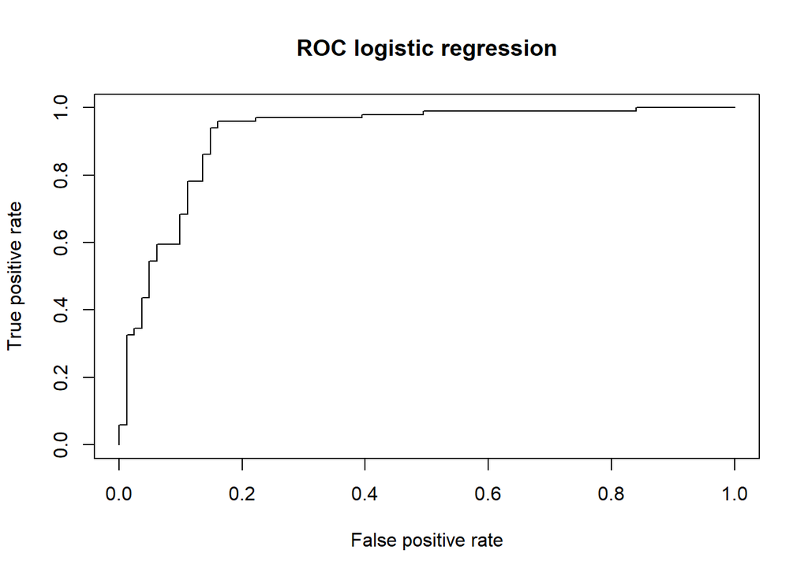

```r
plot(performance(prediction_test_reglog,"tpr","fpr"),main="ROC logistic regression")
```

```r
prediction_knn=prediction(as.numeric(knn_cv)-1,final.test$HeartDisease)
performance(prediction_knn,measure="auc")@y.values
```

```
## [[1]]
## [1] 0.7714216
```

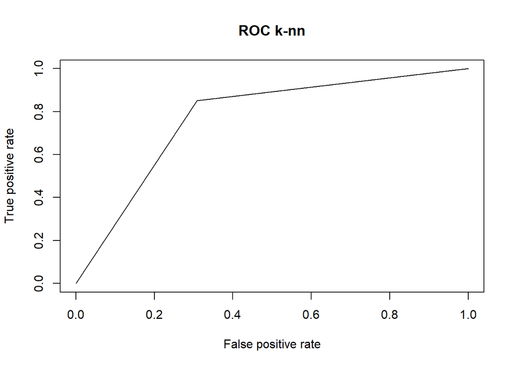

```r
plot(performance(prediction_knn,"tpr","fpr"),main="ROC k-nn")
```

Osservando i valori di AUC possiamo notare come il modello di regressione logistica prevalga nel confronto con il K-NN.

## Soglia

Fino ad ora abbiamo utilizzato una soglia per la probabilità a posteriori pari a 0.5, non è garantito che questa sia la migliore. Ci dedichiamo alla ricerca della soglia ottimale guardando gli error e false positive rate sul training e test set.

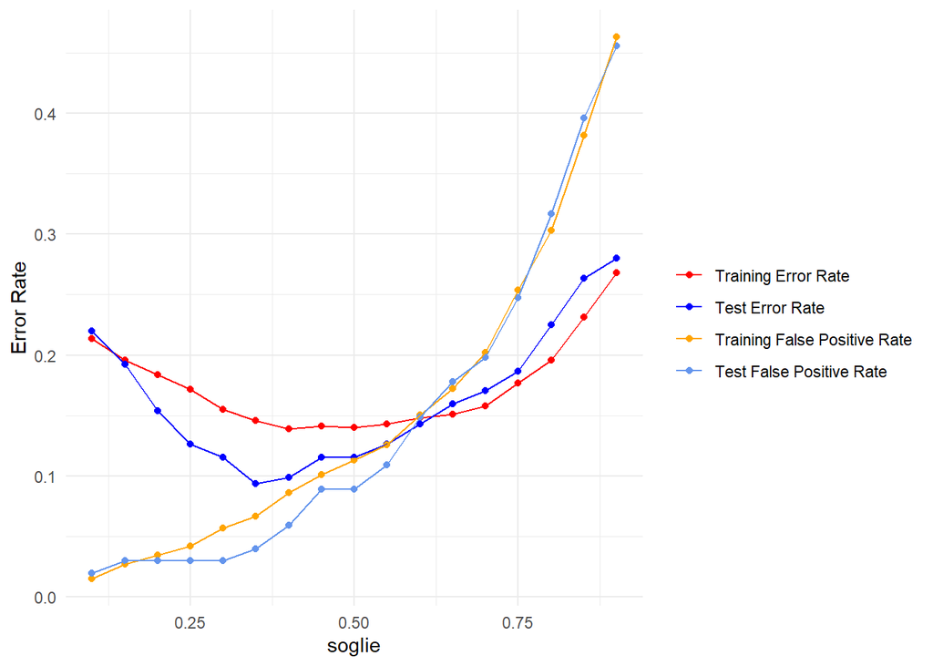

```r
test_train_error=function(soglia,modello=step_reg_log){
  trpred=predict(modello,big_training,type="response")
  testpred=predict(modello,final.test,type="response")
  ptr=ifelse(trpred>soglia,yes = 1,no=0)
  ptest=ifelse(testpred>soglia,1,0)
  met1=1-metriche(table(ptr,big_training$HeartDisease))[1]
  met2=1-metriche(table(ptest,final.test$HeartDisease))[1]
  met3=1-metriche(table(ptr,big_training$HeartDisease))[2]
  met4=1-metriche(table(ptest,final.test$HeartDisease))[2]
  met=rbind(met1,met2,met3,met4)
  rownames(met)=c("training error","test error", "training fp rate","test fp rate")
  colnames(met)="Metriche"
  return(met)
}

test_train_error=Vectorize(test_train_error,vectorize.args = "soglia")
soglie=seq(0.1,0.9,by=0.05)
errors_soglie=as.data.frame(cbind(soglie,t(test_train_error(soglie))))
colnames(errors_soglie)=c("soglie","training_error","test_error","training_fp_rate","test_fp_rate")
ggplot(errors_soglie,aes(x=soglie))+
  geom_point(aes(y=training_error,col="Training Error Rate"))+
  geom_line(aes(y=training_error,col="Training Error Rate"))+
  geom_point(aes(y=test_error,col="Test Error Rate"))+
  geom_point(aes(y=training_fp_rate,col="Training False Positive Rate"))+
  geom_point(aes(y=test_fp_rate,col="Test False Positive Rate"))+
  geom_line(aes(y=test_error,col="Test Error Rate"))+
  geom_line(aes(y=training_fp_rate,col="Training False Positive Rate"))+
  geom_line(aes(y=test_fp_rate,col="Test False Positive Rate"))+
  ylab("Error Rate")+
  theme_minimal()+
  scale_color_manual(name="",breaks=c("Training Error Rate","Test Error Rate","Training False Positive Rate","Test False Positive Rate"),values=c("Training Error Rate"="red","Test Error Rate"="blue",
                                                                  "Training False Positive Rate"="orange","Test False Positive Rate"="cornflowerblue"))
```

Dal grafico possiamo dedurre come la soglia che garantisce i rate minimi sul test sia 0.35.

Determiniamo ulteriori metriche di valutazione con questo nuovo confine e verifichiamo se costituisca un miglioramento delle performance previsionali.

```r
metriche_soglia=cbind(errors_soglie[c(6,9),1],1-errors_soglie[c(6,9),-1])
colnames(metriche_soglia)=c("soglia","training_accuracy","test_accuracy","training_sensitivity","test_sensitivity")
metriche_soglia
```

```
##   soglia training_accuracy test_accuracy training_sensitivity test_sensitivity
## 6   0.35         0.8544218     0.9065934            0.9334975        0.9603960
## 9   0.50         0.8598639     0.8846154            0.8866995        0.9108911
```

Controlliamo se il miglioramento viene confermato anche da metriche più complesse.

```r
prob_reg_log=predict(step_reg_log,final.test,type="response")
pred_reg_log_soglia=ifelse(prob_reg_log>0.35,yes = 1,no=0)
confmat_best_soglia=table(pred_reg_log_soglia,final.test$HeartDisease)
f1scores=cbind(f1_score(confmat_best_soglia),f1_score(confmat_test_stepreglog))
colnames(f1scores)=c("F1 score 0.35","F1 score 0.5")
f1scores
```

```
##      F1 score 0.35 F1 score 0.5
## [1,]     0.9194313     0.897561
```

```r
prob_reglog=predict(step_logistic_mod,validation,type = "response")
logloss_reglog=-mean(step_logistic_mod_pred*log(prob_reglog)+(1-step_logistic_mod_pred)*log(1-prob_reglog))

logloss_reglog_soglia=-mean(pred_reg_log_soglia*log(prob_reg_log)+(1-pred_reg_log_soglia)*log(1-prob_reg_log))
c("Log-loss 0.35"=logloss_reglog_soglia,"Log-loss 0.5"=logloss_reglog)
```

```
## Log-loss 0.35  Log-loss 0.5
##     0.1642174     0.1684336
```

Entrambe confermano il miglioramento dato dallo spostamento della soglia per le posterior probabilities.

## Conclusioni

Dai risultati della sezione precedente possiamo concludere che il modello migliore è il modello di regressione logistica con selezione *stepwise*.

```r
(summ=summary(step_reg_log))
```

```
##
## Call:
## glm(formula = HeartDisease ~ Age + Sex + ChestPainType + FastingBS +
##     ExerciseAngina + Oldpeak + ST_Slope, family = "binomial",
##     data = big_training)
##
## Coefficients:
##                  Estimate Std. Error z value Pr(>|z|)
## (Intercept)       -0.7021     0.5469  -1.284 0.199229
## Age                0.2578     0.1225   2.105 0.035277 *
## SexM               1.5963     0.3120   5.115 3.13e-07 ***
## ChestPainTypeATA  -2.0416     0.3579  -5.705 1.16e-08 ***
## ChestPainTypeNAP  -1.9532     0.2960  -6.599 4.14e-11 ***
## ChestPainTypeTA   -1.5852     0.4581  -3.461 0.000539 ***
## FastingBS1         1.3870     0.2974   4.664 3.10e-06 ***
## ExerciseAnginaY    1.0171     0.2623   3.878 0.000105 ***
## Oldpeak            0.2954     0.1348   2.191 0.028450 *
## ST_SlopeFlat       1.0242     0.4864   2.106 0.035228 *
## ST_SlopeUp        -1.3444     0.5105  -2.634 0.008450 **
## ---
## Signif. codes:  0 '***' 0.001 '**' 0.01 '*' 0.05 '.' 0.1 ' ' 1
##
## (Dispersion parameter for binomial family taken to be 1)
##
##     Null deviance: 1010.84  on 734  degrees of freedom
## Residual deviance:  487.35  on 724  degrees of freedom
## AIC: 509.35
##
## Number of Fisher Scoring iterations: 5
```

Calcoliamo ora le variazioni in percentuale delle odds indotte dalle variabili.

```r
(odds_perc_var=(exp(summ$coefficients[-1,1])-1)*100)
```

```
##              Age             SexM ChestPainTypeATA ChestPainTypeNAP
##         29.41259        393.45487        -87.01827        -85.81858
##  ChestPainTypeTA       FastingBS1  ExerciseAnginaY          Oldpeak
##        -79.50947        300.27286        176.51394         34.36955
##     ST_SlopeFlat       ST_SlopeUp
##        178.49593        -73.93046
```

Guardando le variazioni percentuali,è interessante notare come il sesso maschile sembri essere più portato ad avere problemi cardiaci. Prima di giungere a conclusioni guardiamo le proporzioni in termini di genere e condizione.

```r
table(heart$Sex,heart$HeartDisease)
```

```
##
##       0   1
##   F 143  50
##   M 267 457
```

Dalla tabella risulta evidente uno squilibrio nel sesso delle persone prese in considerazione nello studio. Tuttavia in ambito medico è noto che gli individui di sesso maschile sono più vulnerabili a malattie cardiache in quanto gli estrogeni, maggiormente presenti nelle femmine, proteggono da alcune malattie cardiache.

```r
table(heart$FastingBS,heart$HeartDisease)
```

```
##
##       0   1
##   0 366 337
##   1  44 170
```

Lo stesso discorso può essere fatto per la variabile **FastingBS** in quanto profondamente sbilanciata nella distribuzione.

Una caratteristica che risulta certamente importante è **ST_Slope**,in quanto la sua pendenza è rilevante ai fini di una possibile malattia cardiaca. Dai nostri studi la condizione più favorevole è la pendenza positiva del tratto ST, al contrario un elettrocardiogramma che presenta un segmento ST piatto risulta il caso più avverso.

Come ci si potrebbe aspettare l’invecchiamento risulta in un incremento delle odds di riscontrare problemi cardiaci.

```r
(sqrt(varianze[-c(2,3,4)]))
```

```
##      Age  Oldpeak
## 9.569229 1.068906
```

Avendo trattato le variabili numeriche con una standardizzazione l’incremento dell’odds ratio non è conseguenza di un aumento unitario della variabile, ma di un accrescimento pari al suo scarto quadratico medio. Di conseguenza l’aumento del 29.4% si verifica ogni 9.6 anni.

Un ulteriore campanello d’allarme è il dolore toracico indotto dall’esercizio, che rappresenta un sintomo significativo per l’individuazione di una possibile malattia cardiaca.

Infine è interessante osservare come le categorie di dolore toracico meno preoccupanti per il paziente siano le anginose tipiche e atipiche e la non anginosa. É curioso notare come gli individui privi di dolore al petto risultino i soggetti maggiormente a rischio.

Il modello da noi stimato dopo attente analisi, ha mostrato una buona adattibilità al test set ed eccellenti capacità previsionali. Nonostante il focus della selezione del modello fosse rivolta in primis alla capacità identificativa dei malati, questo ha conseguito ottime performance a 360°.

Modelli di Machine Learning di questo tipo hanno trovato grande spazio nell’ambito biomedico in tempi recenti, dimostrando validità e affidabilità non solo dal punto di vista teorico, ma anche in contesti applicativi.